# Epi 231: Final Project

Pre-incisional antibiotic timing and operative case duration in elective neurosurgery: a retrospective EHR cohort using de-identified UCSF Epic data

# 1 Overview

This notebook documents the full data extraction, cleaning, and analysis workflow for the project *“Pre-incisional antibiotic timing and operative case duration in elective neurosurgery.”* The goals are to:

- Define the analytic cohort and timing exposure using de-identified UCSF Epic data
- Derive comorbidities, labs, provider, and vital sign covariates
- Construct the primary and secondary outcomes
- Perform univariate summaries and nonparametric tests for the prespecified analyses

Where possible, data objects are saved to `.rds` files and reloaded to avoid re-running expensive SQL queries.

```r
library(odbc)
library(DBI)
library(Rcpp)

# Create database connection
con <- DBI::dbConnect(odbc::odbc(), "DEID")
```

# 2 Exposure definition: pre-incisional antibiotic timing

## 2.1 Constructing timing windows from medication administration

We first identify eligible elective neurosurgical cases and compute the minutes between antibiotic administration and incision. We then categorize the timing into clinically motivated windows (0–30, 31–60, 61–120 minutes).

```r
timing_fixed <- dbGetQuery(con, "
WITH eligible_cases AS (
  SELECT
    sc.SurgicalCaseKey,
    sc.EncounterKey,
    sc.ProcedureStartInstant
  FROM deid_uf.SurgicalCaseFact sc
  WHERE sc.SurgeryDateKeyValue BETWEEN '2020-01-01' AND '2022-12-31'
    AND sc.Classification = 'F-Elective'
    AND sc.PatientDurableKey != '-1'
    AND sc.ProcedureStartInstant IS NOT NULL
    AND EXISTS (
      SELECT 1
      FROM deid_uf.SurgicalProcedureEventFact spe
      WHERE spe.SurgicalCaseKey = sc.SurgicalCaseKey
        AND spe.Service = 'Neurological Surgery'
    )
),
abx_ranked AS (
  SELECT
    ec.SurgicalCaseKey,
    DATEDIFF(minute, ma.AdministrationInstant, ec.ProcedureStartInstant) AS minutes_before_incision,
    ROW_NUMBER() OVER (
      PARTITION BY ec.SurgicalCaseKey
      ORDER BY ma.AdministrationInstant DESC
    ) AS rn
  FROM eligible_cases ec
  INNER JOIN deid_uf.MedicationAdministrationFact ma
    ON ec.EncounterKey = ma.EncounterKey
  WHERE ma.AdministrationInstant IS NOT NULL
    AND ma.AdministrationInstant <= ec.ProcedureStartInstant
    AND (
      ma.MedicationGenericName LIKE '%cefazolin%'
      OR ma.MedicationGenericName LIKE '%vancomycin%'
    )
    AND DATEDIFF(minute, ma.AdministrationInstant, ec.ProcedureStartInstant) BETWEEN 0 AND 120
)
SELECT
  CASE
    WHEN minutes_before_incision BETWEEN 0 AND 30 THEN '0-30 min'
    WHEN minutes_before_incision BETWEEN 31 AND 60 THEN '31-60 min'
    WHEN minutes_before_incision BETWEEN 61 AND 120 THEN '61-120 min'
  END AS timing_group,
  COUNT(*) AS n
FROM abx_ranked
WHERE rn = 1
GROUP BY
  CASE
    WHEN minutes_before_incision BETWEEN 0 AND 30 THEN '0-30 min'
    WHEN minutes_before_incision BETWEEN 31 AND 60 THEN '31-60 min'
    WHEN minutes_before_incision BETWEEN 61 AND 120 THEN '61-120 min'
  END
")
timing_fixed
```

| timing_group | n |
| --- | --- |
| 0-30 min | 579 |
| 31-60 min | 202 |
| 61-120 min | 74 |

**Timing categories and rationale**

| Timing window | Category | Rationale |
| --- | --- | --- |
| 0–30 min before incision | Peri-incisional | Very close to incision; antibiotic may not reach peak tissue levels |
| 31–60 min before incision | Optimal window | Guideline-target; likely optimal tissue levels at incision |
| 61–120 min before incision | Early, guideline-acceptable | Still within guideline window; may be relatively early for some agents |

## 2.2 Post-incision sensitivity check (not evaluated)

```r
post_incision_check <- dbGetQuery(con, "
WITH eligible_cases AS (
  SELECT
    sc.SurgicalCaseKey,
    sc.EncounterKey,
    sc.ProcedureStartInstant
  FROM deid_uf.SurgicalCaseFact sc
  WHERE sc.SurgeryDateKeyValue BETWEEN '2020-01-01' AND '2022-12-31'
    AND sc.Classification = 'F-Elective'
    AND sc.PatientDurableKey != '-1'
    AND sc.ProcedureStartInstant IS NOT NULL
    AND EXISTS (
      SELECT 1
      FROM deid_uf.SurgicalProcedureEventFact spe
      WHERE spe.SurgicalCaseKey = sc.SurgicalCaseKey
        AND spe.Service = 'Neurological Surgery'
    )
),
abx_ranked AS (
  SELECT
    ec.SurgicalCaseKey,
    ma.MedicationGenericName,
    DATEDIFF(minute, ma.AdministrationInstant, ec.ProcedureStartInstant) AS minutes_from_abx_to_incision,
    ROW_NUMBER() OVER (
      PARTITION BY sc.SurgicalCaseKey
      ORDER BY ma.AdministrationInstant DESC
    ) as rn
  FROM eligible_cases ec
  INNER JOIN deid_uf.MedicationAdministrationFact ma
    ON ec.EncounterKey = ma.EncounterKey
  WHERE ma.AdministrationInstant IS NOT NULL
    AND (
      ma.MedicationGenericName LIKE '%cefazolin%'
      OR ma.MedicationGenericName LIKE '%vancomycin%'
    )
    AND DATEDIFF(minute, ma.AdministrationInstant, ec.ProcedureStartInstant) BETWEEN -120 AND 120
)
SELECT
  MIN(minutes_from_abx_to_incision) AS min_minute,
  MAX(minutes_from_abx_to_incision) AS max_minute,
  AVG(CAST(minutes_from_abx_to_incision AS FLOAT)) AS mean_minute,
  COUNT(*) AS n_post
FROM abx_ranked
WHERE rn = 1
  AND minutes_from_abx_to_incision < 0
")

post_incision_check
```

# 3 Variable curation: labs and medications

To define clean lab and medication variables, I first pulled broad candidate lists from the EHR tables (for WBC, hemoglobin, and cefazolin/vancomycin), then selected a curated set of component keys and medication keys that match routine preoperative labs and perioperative IV prophylaxis.

## 3.1 Selecting WBC lab components

```r
# wbc_candidates <- dbGetQuery(con, "
#   SELECT DISTINCT
#     r.LabComponentKey,
#     r.ComponentName,
#     t.SpecimenSource
#   FROM deid_uf.LabTestFact t
#   LEFT JOIN deid_uf.LabTestComponentResultMappingFact m
#     ON t.LabTestKey = m.LabTestKey
#   LEFT JOIN deid_uf.LabComponentResultFact r
#     ON r.LabComponentResultKey = m.LabComponentResultKey
#   WHERE (r.ComponentName LIKE '%WBC%' OR r.ComponentName LIKE '%white blood%')
#     AND (t.SpecimenSource IN ('Blood','Whole Blood','Serum','*Unspecified')
#          OR t.SpecimenSource IS NULL)
#   ORDER BY r.ComponentName
# ")
# wbc_candidates
```

Based on this list, I used LabComponentKeys **994**, **6482**, and **30817**, which correspond to standard blood-based WBC measurements.

## 3.2 Selecting hemoglobin lab components

```r
hgb_candidates <- dbGetQuery(con, "
  SELECT DISTINCT
    r.LabComponentKey,
    r.ComponentName,
    t.SpecimenSource
  FROM deid_uf.LabTestFact t
  LEFT JOIN deid_uf.LabTestComponentResultMappingFact m
    ON t.LabTestKey = m.LabTestKey
  LEFT JOIN deid_uf.LabComponentResultFact r
    ON r.LabComponentResultKey = m.LabComponentResultKey
  WHERE r.ComponentName LIKE '%hemoglobin%'
    AND (
      t.SpecimenSource IN ('Blood', 'Whole Blood', 'Serum', '*Unspecified')
      OR t.SpecimenSource IS NULL
    )
  ORDER BY r.ComponentName
")

hgb_candidates
```

From the candidate list, I kept LabComponentKeys 5781, 3902, 6423, 30945, 49582, 5345, 264, and 2888, which all represent hemoglobin measured in blood or whole blood.

```r
med_final_candidates <- dbGetQuery(con, "
  SELECT DISTINCT
    ma.MedicationKey,
    ma.MedicationGenericName,
    md.SimpleGenericName,
    mcd.MedicationForm
  FROM deid_uf.MedicationAdministrationFact ma
  LEFT JOIN deid_uf.MedicationDim md
    ON ma.MedicationKey = md.MedicationKey
  LEFT JOIN deid_uf.MedicationCodeDim mcd
    ON ma.MedicationKey = mcd.MedicationKey
  WHERE ma.MedicationGenericName LIKE '%cefaz%'
     OR ma.MedicationGenericName LIKE '%vanco%'
  ORDER BY md.SimpleGenericName, ma.MedicationGenericName
")
med_final_candidates
```

For cefazolin, I restricted to IV and piggyback formulations that are consistent with perioperative prophylaxis (MedicationKeys 12639, 121147, 275, 239288, 160936, 259931, 113681).

For vancomycin, I selected IV formulations used in perioperative practice (MedicationKeys 49409, 96285, 110324, 235870, 235871, 131620, 199286, 131573, 199165, 237908, 237909, 58605, 256130, 151403, 121548, 238694, 244614, 193623, 77346).

## 3.3 Defining neurosurgical service

```r
dbGetQuery(con, "
SELECT TOP 50
  sc.PrimaryProcedureCptCode,
  sc.PrimaryProcedureName
FROM deid_uf.SurgicalCaseFact sc
JOIN deid_uf.SurgicalProcedureEventFact spe
  ON sc.SurgicalCaseKey = spe.SurgicalCaseKey
WHERE spe.Service = 'Neurological Surgery'
")
```

```r
dbGetQuery(
  con,
  "
  SELECT Distinct(Service)
  FROM deid_uf.SurgicalProcedureEventFact AS spe
  JOIN deid_uf.SurgicalCaseFact AS sc
    ON spe.SurgicalCaseKey = sc.SurgicalCaseKey
  WHERE spe.Service LIKE '%Neuro%'
  "
)
```

| Service |
| --- |
| Radiology Neurological |
| Neurological Surgery |
| Neurological Surgery Peds |
| Neurology |

Based on this list, I restricted the cohort to cases where `spe.Service = 'Neurological Surgery'` in SurgicalProcedureEventFact.

# 4 Cohort construction and cleaning

## 4.1 Main cohort query

The code below defines the analytic cohort of elective neurosurgical cases with a qualifying pre-incisional cefazolin or vancomycin dose within 0–120 minutes before incision. It also computes operative case duration (in minutes), classifies antibiotic class, and assigns each case to a pre-incisional timing group (0–30, 31–60, 61–120 minutes).

Cohort Cleaning

```r
cohort_clean <- dbGetQuery(con, "
  WITH antibiotic_ranked AS (
    SELECT
      sc.SurgicalCaseKey,
      sc.PatientDurableKey,
      sc.EncounterKey,
      sc.SurgeryDateKeyValue,
      sc.ProcedureStartInstant,
      sc.ProcedureCompleteInstant,
      DATEDIFF(minute, sc.ProcedureStartInstant, sc.ProcedureCompleteInstant) AS case_duration_min,
      ma.AdministrationInstant AS antibiotic_instant,
      DATEDIFF(minute, ma.AdministrationInstant, sc.ProcedureStartInstant) AS minutes_before_incision,
      ma.MedicationGenericName AS antibiotic_name,
      CASE
        WHEN ma.MedicationKey IN (12639, 121147, 275, 239288, 160936, 259931, 113681, 189)
          THEN 'Cefazolin'
        WHEN ma.MedicationKey IN (
          49409, 96285, 110324, 235870, 235871, 131620, 199286,
          131573, 199165, 237908, 237909, 58605, 256130, 151403,
          121548, 238694, 244614, 193623, 77346
        )
          THEN 'Vancomycin'
      END AS antibiotic_class,
      ROW_NUMBER() OVER (
        PARTITION BY sc.SurgicalCaseKey
        ORDER BY ma.AdministrationInstant DESC
      ) AS rn -- we want to only keep the antibiotic administered right before incision cause there can be muliplke administrations
    FROM deid_uf.SurgicalCaseFact sc
    INNER JOIN deid_uf.MedicationAdministrationFact ma
      ON sc.EncounterKey = ma.EncounterKey
    WHERE sc.SurgeryDateKeyValue BETWEEN '2020-01-01' AND '2022-12-31'
      AND sc.Classification = 'F-Elective'
      AND sc.PatientDurableKey != '-1'
      AND sc.ProcedureStartInstant IS NOT NULL
      AND ma.AdministrationInstant IS NOT NULL
      AND ma.AdministrationInstant <= sc.ProcedureStartInstant
      AND ma.MedicationKey IN (
        12639, 121147, 275, 239288, 160936, 259931, 113681, 189,
        49409, 96285, 110324, 235870, 235871, 131620, 199286,
        131573, 199165, 237908, 237909, 58605, 256130, 151403,
        121548, 238694, 244614, 193623, 77346
      )
      AND DATEDIFF(minute, ma.AdministrationInstant, sc.ProcedureStartInstant) BETWEEN 0 AND 120
      AND EXISTS (
        SELECT 1
        FROM deid_uf.SurgicalProcedureEventFact spe
        WHERE spe.SurgicalCaseKey = sc.SurgicalCaseKey
          AND spe.Service = 'Neurological Surgery'
      )
  )
  SELECT
    ar.*,
    CASE
      WHEN ar.minutes_before_incision BETWEEN 0 AND 30 THEN '0-30'
      WHEN ar.minutes_before_incision BETWEEN 31 AND 60 THEN '31-60'
      WHEN ar.minutes_before_incision BETWEEN 61 AND 120 THEN '61-120'
    END AS timing_group
  FROM antibiotic_ranked ar
  WHERE ar.rn = 1
")

encounter_class <- dbGetQuery(con, "
  SELECT
    SurgicalCaseKey,
    AdmissionPatientClass
  FROM deid_uf.SurgicalCaseFact
")

cohort_clean <- cohort_clean %>%
  left_join(encounter_class, by = "SurgicalCaseKey") %>%
  mutate(
    AdmissionPatientClass = case_when(
      str_detect(str_to_lower(AdmissionPatientClass), "inpatient") ~ "Inpatient",
      str_detect(str_to_lower(AdmissionPatientClass), "outpatient") ~ "Outpatient",
      TRUE ~ "Other"
    )
  )

print(paste("Clean cohort size:", nrow(cohort_clean)))
print(table(cohort_clean$timing_group, useNA = "ifany"))
print(table(cohort_clean$antibiotic_class, useNA = "ifany"))

saveRDS(cohort_clean, "cohort_clean_revised.rds")
```

## 4.2 Preview of cleaned cohort

```r
cohort_clean <- readRDS("cohort_clean_revised.rds")
head(cohort_clean)
```

|  | SurgicalCaseKey | PatientDurableKey | EncounterKey | SurgeryDateKeyValue | ProcedureStartInstant | ProcedureCompleteInstant | case_duration_min | antibiotic_instant | minutes_before_incision | antibiotic_name | antibiotic_class | rn | timing_group | AdmissionPatientClass |
| --- | --- | --- | --- | --- | --- | --- | --- | --- | --- | --- | --- | --- | --- | --- |
| 1 | DCD9B8C2BFBA71 | DD53E5BE19AB03 | DFB3EE33B8DAD2 | 2022-02-26 | 2022-02-26 18:10:00 | 2022-02-26 21:41:00 | 211 | 2022-02-26 17:59:00 | 11 | ceFAZolin 1 gram solution for injection | Cefazolin | 1 | 0-30 | Inpatient |
| 2 | DCDC56458AAE78 | D2B0619B7ACAF6 | DA59D4B0B5D802 | 2021-06-10 | 2021-06-10 10:35:00 | 2021-06-10 13:02:00 | 147 | 2021-06-10 10:17:00 | 18 | vancomycin 1,000 mg intravenous injection | Vancomycin | 1 | 0-30 | Inpatient |
| 3 | DCE9180A202473 | DABCD162167625 | D280B35C223AC8 | 2020-05-06 | 2020-05-06 14:49:00 | 2020-05-06 19:57:00 | 308 | 2020-05-06 14:00:00 | 49 | vancomycin 500 mg intravenous solution | Vancomycin | 1 | 31-60 | Inpatient |
| 4 | DCEAFDF26C1191 | D381F164C16BF3 | D149EABDB785A8 | 2021-06-22 | 2021-06-22 09:34:00 | 2021-06-22 14:01:00 | 267 | 2021-06-22 09:13:00 | 21 | vancomycin 500 mg intravenous solution | Vancomycin | 1 | 0-30 | Inpatient |
| 5 | DCEC9941ECEF71 | D34773191D2CE8 | D1C67B5CDA928A | 2020-03-26 | 2020-03-26 09:54:00 | 2020-03-26 12:40:00 | 166 | 2020-03-26 09:37:00 | 17 | vancomycin 500 mg intravenous solution | Vancomycin | 1 | 0-30 | Inpatient |
| 6 | DCF70544DC44DA | D649EA935D0065 | DF72E4436AFE96 | 2021-01-22 | 2021-01-22 08:44:00 | 2021-01-22 10:17:00 | 93 | 2021-01-22 08:22:00 | 22 | vancomycin 500 mg intravenous solution | Vancomycin | 1 | 0-30 | Inpatient |

```r
table(cohort_clean$timing_group)
```

```
##
##   0-30  31-60 61-120
##    579    202     74
```

```r
table(cohort_clean$antibiotic_class)
```

```
##
##  Cefazolin Vancomycin
##        359        496
```

# 5 Demographics and age restriction

Here I link the cohort to PatDurableDim to add sex, race/ethnicity, and birthdate, compute age at surgery, restrict to adults aged 18–100 years, and define the primary 2-group exposure (0–30 vs 31–120 minutes before incision).

```r
demo <- dbGetQuery(con, "
  SELECT
    PatientDurableKey,
    Sex,
    UCSFDerivedRaceEthnicity_X AS RaceEthnicity,
    BirthDate
  FROM deid_uf.PatDurableDim
  WHERE PatientDurableKey != '-1'
")

cohort_demo <- cohort_clean %>%
  left_join(demo, by = "PatientDurableKey") %>%
  mutate(
    Age = as.numeric(difftime(SurgeryDateKeyValue, BirthDate, units = 'days')) / 365.25
  )

cohort_clean_age <- cohort_demo %>%
  filter(Age >= 18, Age <= 100) %>%
  mutate(
    timing_group_main = case_when(
      timing_group == "0-30" ~ "0-30",
      timing_group %in% c("31-60", "61-120") ~ "31-120",
      TRUE ~ NA_character_
    )
  )

print(paste("Cohort after age cleaning:", nrow(cohort_clean_age)))
print(paste("Excluded:", nrow(cohort_demo) - nrow(cohort_clean_age), "cases"))

cohort_clean_age %>%
  group_by(timing_group) %>%
  summarise(
    n = n(),
    mean_age = mean(Age, na.rm = TRUE),
    sd_age = sd(Age, na.rm = TRUE),
    min_age = min(Age, na.rm = TRUE),
    max_age = max(Age, na.rm = TRUE),
    median_age = median(Age, na.rm = TRUE)
  )

# print(table(cohort_clean_age$timing_group, cohort_clean_age$Sex, useNA = "ifany"))
# print(table(cohort_clean_age$timing_group, cohort_clean_age$RaceEthnicity, useNA = "ifany"))
# print(table(cohort_clean_age$timing_group_main, useNA = "ifany"))

saveRDS(cohort_clean_age, "cohort_clean_age_revised.rds")
```

## 5.1 Preview of cohort with age and primary timing exposure

```r
cohort_clean_age <- readRDS("cohort_clean_age_revised.rds")
head(cohort_clean_age)
```

|  | SurgicalCaseKey | PatientDurableKey | EncounterKey | SurgeryDateKeyValue | ProcedureStartInstant | ProcedureCompleteInstant | case_duration_min | antibiotic_instant | minutes_before_incision | antibiotic_name | antibiotic_class | rn | timing_group | AdmissionPatientClass | Sex | RaceEthnicity | BirthDate | Age | timing_group_main |
| --- | --- | --- | --- | --- | --- | --- | --- | --- | --- | --- | --- | --- | --- | --- | --- | --- | --- | --- | --- |
| 1 | DCD9B8C2BFBA71 | DD53E5BE19AB03 | DFB3EE33B8DAD2 | 2022-02-26 | 2022-02-26 18:10:00 | 2022-02-26 21:41:00 | 211 | 2022-02-26 17:59:00 | 11 | ceFAZolin 1 gram solution for injection | Cefazolin | 1 | 0-30 | Inpatient | Female | White | 1966-07-03 | 55.65229 | 0-30 |
| 2 | DCE9180A202473 | DABCD162167625 | D280B35C223AC8 | 2020-05-06 | 2020-05-06 14:49:00 | 2020-05-06 19:57:00 | 308 | 2020-05-06 14:00:00 | 49 | vancomycin 500 mg intravenous solution | Vancomycin | 1 | 31-60 | Inpatient | Male | White | 1982-11-02 | 37.50856 | 31-120 |
| 3 | DCEAFDF26C1191 | D381F164C16BF3 | D149EABDB785A8 | 2021-06-22 | 2021-06-22 09:34:00 | 2021-06-22 14:01:00 | 267 | 2021-06-22 09:13:00 | 21 | vancomycin 500 mg intravenous solution | Vancomycin | 1 | 0-30 | Inpatient | Male | Latinx | 1957-11-10 | 63.61396 | 0-30 |
| 4 | DCEC9941ECEF71 | D34773191D2CE8 | D1C67B5CDA928A | 2020-03-26 | 2020-03-26 09:54:00 | 2020-03-26 12:40:00 | 166 | 2020-03-26 09:37:00 | 17 | vancomycin 500 mg intravenous solution | Vancomycin | 1 | 0-30 | Inpatient | Female | White | 1963-05-25 | 56.83778 | 0-30 |
| 5 | DCF70544DC44DA | D649EA935D0065 | DF72E4436AFE96 | 2021-01-22 | 2021-01-22 08:44:00 | 2021-01-22 10:17:00 | 93 | 2021-01-22 08:22:00 | 22 | vancomycin 500 mg intravenous solution | Vancomycin | 1 | 0-30 | Inpatient | Female | White | 1977-10-21 | 43.25530 | 0-30 |
| 6 | DCFCDC24A11F2B | DCBE8A891A5B86 | D3169EFF86718E | 2020-09-22 | 2020-09-22 13:42:00 | 2020-09-22 16:42:00 | 180 | 2020-09-22 13:00:00 | 42 | vancomycin 500 mg intravenous solution | Vancomycin | 1 | 31-60 | Inpatient | Male | White | 1988-03-05 | 32.55031 | 31-120 |

```r
table(cohort_clean_age$timing_group_main)
```

```
##
##   0-30 31-120
##    566    260
```

# 6 Comorbidities (ICD-10 –> ValueSetEpicId)

Originally, I defined binary comorbidity indicators for diabetes, hypertension, obesity, smoking, and cancer using ICD-10-CM diagnosis codes recorded within 12 months before the surgery date for each case.

https://www.icd10data.com/ICD10CM/Codes/E00-E89/E08-E13

```r
#comorbidities
cohort_index <- cohort_clean_age %>%
  select(SurgicalCaseKey, PatientDurableKey, SurgeryDateKeyValue, timing_group, timing_group_main) %>%
  distinct()

print(paste("Index surgical cases:", nrow(cohort_index)))
print(paste("Unique patients:", n_distinct(cohort_index$PatientDurableKey)))
```

Because pulling diagnosis history for all cases at once was too slow, I split the cohort into smaller batches and extracted comorbidities for each batch.

```r
get_comorb_batch <- function(batch_df, con) {
  case_list <- paste(batch_df$SurgicalCaseKey, collapse = "','")

  sql <- sprintf("
    SELECT
      idx.SurgicalCaseKey,
      MAX(CASE WHEN dtd.Value LIKE 'E08%%' OR dtd.Value LIKE 'E09%%' OR dtd.Value LIKE 'E10%%' OR dtd.Value LIKE 'E11%%' OR dtd.Value LIKE 'E13%%' THEN 1 ELSE 0 END) AS diabetes,
      MAX(CASE WHEN dtd.Value LIKE 'I10%%' OR dtd.Value LIKE 'I11%%' OR dtd.Value LIKE 'I12%%' OR dtd.Value LIKE 'I13%%' THEN 1 ELSE 0 END) AS hypertension,
      MAX(CASE WHEN dtd.Value LIKE 'E66%%' THEN 1 ELSE 0 END) AS obesity,
      MAX(CASE WHEN dtd.Value LIKE 'F17%%' OR dtd.Value LIKE 'Z87.891%%' THEN 1 ELSE 0 END) AS smoking,
      MAX(CASE WHEN dtd.Value LIKE 'C%%' THEN 1 ELSE 0 END) AS cancer
    FROM (
      SELECT DISTINCT SurgicalCaseKey, PatientDurableKey, SurgeryDateKeyValue
      FROM deid_uf.SurgicalCaseFact
      WHERE SurgicalCaseKey IN ('%s')
    ) idx
    LEFT JOIN deid_uf.DiagnosisEventFact de
      ON idx.PatientDurableKey = de.PatientDurableKey
      AND de.StartDateKeyValue >= DATEADD(month, -12, idx.SurgeryDateKeyValue)
      AND de.StartDateKeyValue < idx.SurgeryDateKeyValue
    LEFT JOIN deid_uf.DiagnosisTerminologyDim dtd
      ON de.DiagnosisKey = dtd.DiagnosisKey
      AND dtd.Type = 'ICD-10-CM'
    GROUP BY idx.SurgicalCaseKey", case_list)

  dbGetQuery(con, sql)
}
```

Relevant diagnosis groupers were then explored using DiagnosisSetDim (e.g., EDG CONCEPT DIABETES MELLITUS, EDG CONCEPT HYPERTENSION, EDG CONCEPT OBESITY, EDG CONCEPT HP TOBACCO USE, and EDG CONCEPT CANCER). These groupers were used to approximate comorbid conditions using their corresponding ValueSetEpicId values.

```r
grouper_search <- dbGetQuery(con, "
  SELECT DISTINCT
    Name, ValueSetEpicID
  FROM deid_uf.DiagnosisSetDim
  WHERE Name LIKE '%diabet%'
     OR Name LIKE '%hypertens%'
     OR Name LIKE '%obes%'
     OR Name LIKE '%smok%'
     OR Name LIKE '%tobacco%'
     OR Name LIKE '%cancer%'
     OR Name LIKE '%neoplasm%'
  ORDER BY Name
")
grouper_search
```

For groupers, we found Diabetes ValueSetEpicId = 210000, Hypertension ValueSetEpicId = 100002, Obesity ValueSetEpicId = 100128, Smoking ValueSetEpicId = 159000010, and Cancer ValueSetEpicId = 2100000011

```r
#I had to process in batche since my code kept crashign

case_batches <- split(cohort_index, ceiling(seq_len(nrow(cohort_index)) / 100))

get_comorb_batch_grouper <- function(batch_df, con) {
  case_list <- paste(batch_df$SurgicalCaseKey, collapse = "','")

  sql <- sprintf("
    SELECT
      idx.SurgicalCaseKey,
      MAX(CASE WHEN dsd.ValueSetEpicId = '210000' THEN 1 ELSE 0 END) AS diabetes,
      MAX(CASE WHEN dsd.ValueSetEpicId = '100002' THEN 1 ELSE 0 END) AS hypertension,
      MAX(CASE WHEN dsd.ValueSetEpicId = '100128' THEN 1 ELSE 0 END) AS obesity,
      MAX(CASE WHEN dsd.ValueSetEpicId = '159000010' THEN 1 ELSE 0 END) AS smoking,
      MAX(CASE WHEN dsd.ValueSetEpicId = '2100000011' THEN 1 ELSE 0 END) AS cancer
    FROM (
      SELECT DISTINCT
        SurgicalCaseKey,
        PatientDurableKey,
        SurgeryDateKeyValue
      FROM deid_uf.SurgicalCaseFact
      WHERE SurgicalCaseKey IN ('%s')
    ) idx
    LEFT JOIN deid_uf.DiagnosisEventFact de
      ON idx.PatientDurableKey = de.PatientDurableKey
      AND de.StartDateKeyValue >= DATEADD(month, -12, idx.SurgeryDateKeyValue)
      AND de.StartDateKeyValue < idx.SurgeryDateKeyValue
    LEFT JOIN deid_uf.DiagnosisSetDim dsd
      ON de.DiagnosisKey = dsd.DiagnosisKey
    GROUP BY idx.SurgicalCaseKey
  ", case_list)

  dbGetQuery(con, sql)
}
```

```r
comorb_list <- vector("list", length(case_batches))

for (i in seq_along(case_batches)) {
  print(paste("Running batch", i, "of", length(case_batches)))
  comorb_list[[i]] <- get_comorb_batch_grouper(case_batches[[i]], con)
}

comorb_all <- bind_rows(comorb_list)

print(dim(comorb_all))
head(comorb_all)

saveRDS(comorb_all, "comorb_all_groupers.rds")
```

```r
comorb_all <- readRDS("comorb_all_groupers.rds")
```

## 6.1 Merging comorbidities into the analytic cohort

Next, I merge the comorbidity indicators back into the cleaned cohort and replace missing values with 0 (interpreted as absence of the comorbidity).

```r
cohort_with_comorb <- cohort_clean_age %>%
  left_join(comorb_all, by = "SurgicalCaseKey") %>%
  mutate(
    diabetes = replace_na(diabetes, 0),
    hypertension = replace_na(hypertension, 0),
    obesity = replace_na(obesity, 0),
    smoking = replace_na(smoking, 0),
    cancer = replace_na(cancer, 0)
  )

cohort_with_comorb %>%
  group_by(timing_group_main) %>%
  summarise(
    n = n(),
    diabetes = mean(diabetes) * 100,
    hypertension = mean(hypertension) * 100,
    obesity = mean(obesity) * 100,
    smoking = mean(smoking) * 100,
    cancer = mean(cancer) * 100
  )

saveRDS(cohort_with_comorb, "cohort_with_comorb.rds")
print("Saved cohort_with_comorb.rds")
```

## 6.2 Preview

```r
cohort_with_comorb <- readRDS("cohort_with_comorb.rds")
head(cohort_with_comorb)
```

|  | SurgicalCaseKey | PatientDurableKey | EncounterKey | SurgeryDateKeyValue | ProcedureStartInstant | ProcedureCompleteInstant | case_duration_min | antibiotic_instant | minutes_before_incision | antibiotic_name | antibiotic_class | rn | timing_group | AdmissionPatientClass | Sex | RaceEthnicity | BirthDate | Age | timing_group_main | diabetes | hypertension | obesity | smoking | cancer |
| --- | --- | --- | --- | --- | --- | --- | --- | --- | --- | --- | --- | --- | --- | --- | --- | --- | --- | --- | --- | --- | --- | --- | --- | --- |
| 1 | DCD9B8C2BFBA71 | DD53E5BE19AB03 | DFB3EE33B8DAD2 | 2022-02-26 | 2022-02-26 18:10:00 | 2022-02-26 21:41:00 | 211 | 2022-02-26 17:59:00 | 11 | ceFAZolin 1 gram solution for injection | Cefazolin | 1 | 0-30 | Inpatient | Female | White | 1966-07-03 | 55.65229 | 0-30 | 0 | 0 | 0 | 0 | 0 |
| 2 | DCE9180A202473 | DABCD162167625 | D280B35C223AC8 | 2020-05-06 | 2020-05-06 14:49:00 | 2020-05-06 19:57:00 | 308 | 2020-05-06 14:00:00 | 49 | vancomycin 500 mg intravenous solution | Vancomycin | 1 | 31-60 | Inpatient | Male | White | 1982-11-02 | 37.50856 | 31-120 | 0 | 0 | 0 | 0 | 0 |
| 3 | DCEAFDF26C1191 | D381F164C16BF3 | D149EABDB785A8 | 2021-06-22 | 2021-06-22 09:34:00 | 2021-06-22 14:01:00 | 267 | 2021-06-22 09:13:00 | 21 | vancomycin 500 mg intravenous solution | Vancomycin | 1 | 0-30 | Inpatient | Male | Latinx | 1957-11-10 | 63.61396 | 0-30 | 0 | 1 | 0 | 0 | 1 |
| 4 | DCEC9941ECEF71 | D34773191D2CE8 | D1C67B5CDA928A | 2020-03-26 | 2020-03-26 09:54:00 | 2020-03-26 12:40:00 | 166 | 2020-03-26 09:37:00 | 17 | vancomycin 500 mg intravenous solution | Vancomycin | 1 | 0-30 | Inpatient | Female | White | 1963-05-25 | 56.83778 | 0-30 | 0 | 0 | 0 | 0 | 1 |
| 5 | DCF70544DC44DA | D649EA935D0065 | DF72E4436AFE96 | 2021-01-22 | 2021-01-22 08:44:00 | 2021-01-22 10:17:00 | 93 | 2021-01-22 08:22:00 | 22 | vancomycin 500 mg intravenous solution | Vancomycin | 1 | 0-30 | Inpatient | Female | White | 1977-10-21 | 43.25530 | 0-30 | 0 | 0 | 0 | 0 | 1 |
| 6 | DCFCDC24A11F2B | DCBE8A891A5B86 | D3169EFF86718E | 2020-09-22 | 2020-09-22 13:42:00 | 2020-09-22 16:42:00 | 180 | 2020-09-22 13:00:00 | 42 | vancomycin 500 mg intravenous solution | Vancomycin | 1 | 31-60 | Inpatient | Male | White | 1988-03-05 | 32.55031 | 31-120 | 0 | 0 | 0 | 0 | 0 |

# 7 Laboratory values (preoperative WBC and hemoglobin)

I use curated lab component keys to extract WBC and hemoglobin values from the beginning of the file, then keep the most recent measurement within 30 days before surgery for each case to represent preoperative lab

```r
wbc_all <- dbGetQuery(con, "
  SELECT
    PatientDurableKey,
    CollectionDateKeyValue AS lab_date,
    ComponentName,
    LabComponentKey,
    TRY_CAST(Value AS FLOAT) AS wbc_value,
    Unit
  FROM deid_uf.LabComponentResultFact
  WHERE PatientDurableKey != '-1'
    AND CollectionDateKeyValue BETWEEN '2019-01-01' AND '2022-12-31'
    AND LabComponentKey IN (994, 6482, 30817)
")

print(dim(wbc_all))
head(wbc_all)

saveRDS(wbc_all, "wbc_all.rds")
print("Saved wbc_all.rds")
```

```r
hgb_all <- dbGetQuery(con, "
  SELECT
    PatientDurableKey,
    CollectionDateKeyValue AS lab_date,
    ComponentName,
    LabComponentKey,
    TRY_CAST(Value AS FLOAT) AS hgb_value,
    Unit
  FROM deid_uf.LabComponentResultFact
  WHERE PatientDurableKey != '-1'
    AND CollectionDateKeyValue BETWEEN '2019-01-01' AND '2022-12-31'
    AND LabComponentKey IN (5781, 3902, 6423, 30945, 49582, 5345, 264, 2888)
")

print(dim(hgb_all))
head(hgb_all)

saveRDS(hgb_all, "hgb_all.rds")
print("Saved hgb_all.rds")
```

## 7.1 Preview of raw lab data

```r
cohort_with_comorb <- readRDS("cohort_with_comorb.rds")
wbc_all <- readRDS("wbc_all.rds")
hgb_all <- readRDS("hgb_all.rds")
head(wbc_all)
```

|  | PatientDurableKey | lab_date | ComponentName | LabComponentKey | wbc_value | Unit |
| --- | --- | --- | --- | --- | --- | --- |
| 1 | DE73DE0D0541B8 | 2020-08-25 | WBC Count | 994 | 5.3 | TH/mm3 |
| 2 | D31D732C8EF788 | 2022-09-08 | WBC Count | 994 | 7.2 | TH/mm3 |
| 3 | DAC8F92E01FE39 | 2021-01-22 | WBC Count | 994 | 9.4 | TH/mm3 |
| 4 | DAC8F92E01FE39 | 2021-03-01 | WBC Count | 994 | 7.8 | TH/mm3 |
| 5 | DDABEDE033DF53 | 2020-10-31 | WBC Count | 994 | 6.7 | TH/mm3 |
| 6 | D240C999F68345 | 2021-03-17 | WBC Count | 994 | 8.4 | TH/mm3 |

```r
head(hgb_all)
```

|  | PatientDurableKey | lab_date | ComponentName | LabComponentKey | hgb_value | Unit |
| --- | --- | --- | --- | --- | --- | --- |
| 1 | D8DEA5036DC992 | 2020-05-10 | Hemoglobin | 5345 | 13.8 | g/dL |
| 2 | D6675FE1C6B7B2 | 2021-04-29 | Hemoglobin | 5345 | 13.1 | g/dL |
| 3 | D231FDD2ACAB72 | 2022-03-13 | Hemoglobin | 5345 | 12.4 | g/dL |
| 4 | D54CE0345C39C0 | 2022-10-08 | Hemoglobin | 5345 | 15.6 | g/dL |
| 5 | D95D7C8A2AC5A6 | 2022-07-19 | Hemoglobin | 5345 | 12.2 | g/dL |
| 6 | DA831621790FF1 | 2022-01-16 | Hemoglobin | 5345 | 14.1 | g/dL |

## 7.2 Defining preoperative lab window (30 days)

Next, I link lab results to surgery dates and keep the most recent WBC and hemoglobin measured within 30 days before each surgery.

```r
surgery_dates <- cohort_with_comorb %>%
  select(SurgicalCaseKey, PatientDurableKey, SurgeryDateKeyValue, Sex, timing_group, timing_group_main) %>%
  distinct()

wbc_preop <- wbc_all %>%
  semi_join(surgery_dates, by = "PatientDurableKey") %>%
  mutate(lab_date = as.Date(lab_date)) %>%
  inner_join(surgery_dates, by = "PatientDurableKey") %>%
  filter(
    lab_date >= SurgeryDateKeyValue - 30,
    lab_date < SurgeryDateKeyValue
  ) %>%
  group_by(SurgicalCaseKey) %>%
  slice_max(lab_date, n = 1, with_ties = FALSE) %>%
  ungroup() %>%
  select(SurgicalCaseKey, preop_wbc = wbc_value, preop_wbc_date = lab_date, preop_wbc_unit = Unit)

print(dim(wbc_preop))
head(wbc_preop)

saveRDS(wbc_preop, "wbc_preop_groupers.rds")
print("Saved wbc_preop_groupers.rds")
```

```r
hgb_preop <- hgb_all %>%
  semi_join(surgery_dates, by = "PatientDurableKey") %>%
  mutate(lab_date = as.Date(lab_date)) %>%
  inner_join(surgery_dates, by = "PatientDurableKey", relationship = "many-to-many") %>%
  filter(
    lab_date >= SurgeryDateKeyValue - 30,
    lab_date < SurgeryDateKeyValue
  ) %>%
  group_by(SurgicalCaseKey) %>%
  slice_max(lab_date, n = 1, with_ties = FALSE) %>%
  ungroup() %>%
  select(SurgicalCaseKey, preop_hgb = hgb_value, preop_hgb_date = lab_date, preop_hgb_unit = Unit)

print(dim(hgb_preop))
head(hgb_preop)

saveRDS(hgb_preop, "hgb_preop_groupers.rds")
print("Saved hgb_preop_groupers.rds")
```

## 7.3 Preview of preoperative lab values

```r
wbc_preop <- readRDS("wbc_preop_groupers.rds")
hgb_preop <- readRDS("hgb_preop_groupers.rds")
head(wbc_preop)
```

| SurgicalCaseKey | preop_wbc | preop_wbc_date | preop_wbc_unit |
| --- | --- | --- | --- |
| D001ADA1689CCD | 7.1 | 2022-09-21 | x10E3/uL |
| D003B706664D52 | 5.1 | 2020-01-07 | x10E9/L |
| D0096415F0A01F | 7.1 | 2021-11-20 | x10E9/L |
| D00DA8F308CE67 | 7.4 | 2021-01-26 | x10E9/L |
| D01EDBEFF7A95E | 6.2 | 2022-03-05 | Thousand/uL |
| D02336117F9F3E | 4.6 | 2022-05-30 | Thousand/uL |

```r
head(hgb_preop)
```

| SurgicalCaseKey | preop_hgb | preop_hgb_date | preop_hgb_unit |
| --- | --- | --- | --- |
| D001ADA1689CCD | 12.0 | 2022-09-21 | g/dL |
| D003B706664D52 | 11.8 | 2020-01-07 | g/dL |
| D0096415F0A01F | 13.6 | 2021-11-20 | g/dL |
| D00DA8F308CE67 | 14.2 | 2021-01-26 | g/dL |
| D01EDBEFF7A95E | 13.0 | 2022-03-05 | g/dL |
| D02336117F9F3E | 12.6 | 2022-05-30 | g/dL |

## 7.4 Lab-derived covariates

Here I merge the preoperative WBC and hemoglobin into the cohort and define binary indicators for elevated WBC (≥10) and anemia (sex-specific hemoglobin thresholds).

```r
cohort_with_labs <- cohort_with_comorb %>%
  left_join(wbc_preop, by = "SurgicalCaseKey") %>%
  left_join(hgb_preop, by = "SurgicalCaseKey") %>%
  mutate(
    wbc_high = case_when(
      is.na(preop_wbc) ~ NA_real_,
      preop_wbc >= 10 ~ 1,
      TRUE ~ 0
    ),
    hgb_low = case_when(
      is.na(preop_hgb) ~ NA_real_,
      Sex == "Male" & preop_hgb < 13 ~ 1,
      Sex == "Female" & preop_hgb < 12 ~ 1,
      TRUE ~ 0
    )
  )

print("Lab availability:")
cohort_with_labs %>%
  summarise(
    n_total = n(),
    n_wbc = sum(!is.na(preop_wbc)),
    n_hgb = sum(!is.na(preop_hgb)),
    pct_wbc = round(mean(!is.na(preop_wbc)) * 100, 1),
    pct_hgb = round(mean(!is.na(preop_hgb)) * 100, 1)
  )

saveRDS(cohort_with_labs, "cohort_with_labs_groupers.rds")
print("Saved cohort_with_labs_groupers.rds")
```

```r
cohort_with_labs <- readRDS("cohort_with_labs_groupers.rds")
head(cohort_with_labs)
```

|  | SurgicalCaseKey | PatientDurableKey | EncounterKey | SurgeryDateKeyValue | ProcedureStartInstant | ProcedureCompleteInstant | case_duration_min | antibiotic_instant | minutes_before_incision | antibiotic_name | antibiotic_class | rn | timing_group | AdmissionPatientClass | Sex | RaceEthnicity | BirthDate | Age | timing_group_main | diabetes | hypertension | obesity | smoking | cancer | preop_wbc | preop_wbc_date | preop_wbc_unit | preop_hgb | preop_hgb_date | … |
| --- | --- | --- | --- | --- | --- | --- | --- | --- | --- | --- | --- | --- | --- | --- | --- | --- | --- | --- | --- | --- | --- | --- | --- | --- | --- | --- | --- | --- | --- | --- |
| 1 | DCD9B8C2BFBA71 | DD53E5BE19AB03 | DFB3EE33B8DAD2 | 2022-02-26 | 2022-02-26 18:10:00 | 2022-02-26 21:41:00 | 211 | 2022-02-26 17:59:00 | 11 | ceFAZolin 1 gram solution for injection | Cefazolin | 1 | 0-30 | Inpatient | Female | White | 1966-07-03 | 55.65229 | 0-30 | 0 | 0 | 0 | 0 | 0 | NA |  | NA | NA |  | … |
| 2 | DCE9180A202473 | DABCD162167625 | D280B35C223AC8 | 2020-05-06 | 2020-05-06 14:49:00 | 2020-05-06 19:57:00 | 308 | 2020-05-06 14:00:00 | 49 | vancomycin 500 mg intravenous solution | Vancomycin | 1 | 31-60 | Inpatient | Male | White | 1982-11-02 | 37.50856 | 31-120 | 0 | 0 | 0 | 0 | 0 | 11.7 | 2020-05-05 | x10E9/L | 10.8 | 2020-05-05 | … |
| 3 | DCEAFDF26C1191 | D381F164C16BF3 | D149EABDB785A8 | 2021-06-22 | 2021-06-22 09:34:00 | 2021-06-22 14:01:00 | 267 | 2021-06-22 09:13:00 | 21 | vancomycin 500 mg intravenous solution | Vancomycin | 1 | 0-30 | Inpatient | Male | Latinx | 1957-11-10 | 63.61396 | 0-30 | 0 | 1 | 0 | 0 | 1 | 7.3 | 2021-06-21 | x10E9/L | 14.4 | 2021-06-21 | … |
| 4 | DCEC9941ECEF71 | D34773191D2CE8 | D1C67B5CDA928A | 2020-03-26 | 2020-03-26 09:54:00 | 2020-03-26 12:40:00 | 166 | 2020-03-26 09:37:00 | 17 | vancomycin 500 mg intravenous solution | Vancomycin | 1 | 0-30 | Inpatient | Female | White | 1963-05-25 | 56.83778 | 0-30 | 0 | 0 | 0 | 0 | 1 | 4.6 | 2020-03-25 | x10E9/L | 13.8 | 2020-03-25 | … |
| 5 | DCF70544DC44DA | D649EA935D0065 | DF72E4436AFE96 | 2021-01-22 | 2021-01-22 08:44:00 | 2021-01-22 10:17:00 | 93 | 2021-01-22 08:22:00 | 22 | vancomycin 500 mg intravenous solution | Vancomycin | 1 | 0-30 | Inpatient | Female | White | 1977-10-21 | 43.25530 | 0-30 | 0 | 0 | 0 | 0 | 1 | 17.9 | 2021-01-18 | Thousand/uL | 15.7 | 2021-01-18 | … |
| 6 | DCFCDC24A11F2B | DCBE8A891A5B86 | D3169EFF86718E | 2020-09-22 | 2020-09-22 13:42:00 | 2020-09-22 16:42:00 | 180 | 2020-09-22 13:00:00 | 42 | vancomycin 500 mg intravenous solution | Vancomycin | 1 | 31-60 | Inpatient | Male | White | 1988-03-05 | 32.55031 | 31-120 | 0 | 0 | 0 | 0 | 0 | 6.0 | 2020-09-21 | x10E9/L | 15.5 | 2020-09-21 | … |

# 8 Provider characteristics

I use AttendingProviderPrimarySpecialty as a proxy for provider characteristics, since ProviderType was unspecified for all cases.

```r
provider_info <- dbGetQuery(con, sprintf("
  SELECT
    EncounterKey,
    ProviderType,
    ProviderPrimarySpecialty,
    AttendingProviderType,
    AttendingProviderPrimarySpecialty
  FROM deid_uf.EncounterFact
  WHERE EncounterKey IN ('%s')
", paste(cohort_with_labs$EncounterKey, collapse = "','")))
provider_info

cohort_with_prov <- cohort_with_labs %>%
  left_join(provider_info %>% select(EncounterKey, AttendingProviderPrimarySpecialty), by = "EncounterKey")

saveRDS(cohort_with_prov, "cohort_with_prov_groupers.rds")
cohort_with_prov
```

```r
cohort_with_prov <- readRDS("cohort_with_prov_groupers.rds")
head(cohort_with_prov[c("SurgicalCaseKey", "AttendingProviderPrimarySpecialty")])
```

|  | SurgicalCaseKey | AttendingProviderPrimarySpecialty |
| --- | --- | --- |
| 1 | DCD9B8C2BFBA71 | Neurosurgery |
| 2 | DCE9180A202473 | Neurosurgery |
| 3 | DCEAFDF26C1191 | Neurosurgery |
| 4 | DCEC9941ECEF71 | Neurosurgery |
| 5 | DCF70544DC44DA | Neurosurgery |
| 6 | DCFCDC24A11F2B | Neurosurgery |

```r
table(cohort_with_prov$AttendingProviderPrimarySpecialty, useNA = "ifany")
```

```
##
##                        Anesthesiology                Critical Care Medicine
##                                    10                                     1
##                            Hematology                     Hospital Medicine
##                                     4                                     9
##                      Medical Oncology                             Neurology
##                                     3                                     4
##                          Neurosurgery                    Orthopedic Surgery
##                                   787                                     2
## Otolaryngology, Head and Neck Surgery              Palliative Care Medicine
##                                     1                                     3
##                      Thoracic Surgery                            Transplant
##                                     1                                     1
```

# 9 Vital signs (preoperative heart rate)

```r
hr_all <- dbGetQuery(con, sprintf("
  SELECT
    PatientDurableKey,
    EncounterKey,
    FlowsheetRowKey,
    DateKeyValue,
    TakenInstant,
    NumericValue,
    FlowsheetRowUnit
  FROM deid_uf.FlowsheetValueFact
  WHERE PatientDurableKey != '-1'
    AND FlowsheetRowKey = 61799
    AND NumericValue IS NOT NULL
    AND PatientDurableKey IN ('%s')
", paste(unique(cohort_with_prov$PatientDurableKey), collapse = "','")))

hr_all

hr_preop <- hr_all %>%
  mutate(
    TakenInstant = as.POSIXct(TakenInstant),
    DateKeyValue = as.Date(DateKeyValue)
  ) %>%
  inner_join(
    cohort_with_prov %>%
      select(SurgicalCaseKey, PatientDurableKey, ProcedureStartInstant),
    by = "PatientDurableKey"
  ) %>%
  filter(
    TakenInstant < ProcedureStartInstant,
    TakenInstant >= ProcedureStartInstant - lubridate::days(30)
  ) %>%
  group_by(SurgicalCaseKey) %>%
  slice_max(TakenInstant, n = 1, with_ties = FALSE) %>%
  ungroup() %>%
  select(SurgicalCaseKey, preop_hr = hr_value)

cohort_with_vitals <- cohort_with_prov %>%
  left_join(hr_preop, by = "SurgicalCaseKey")
cohort_with_vitals
```

# 10 Baseline characteristics (Table 1)

```r
library(tableone)
library(forcats)

cohort_with_prov <- readRDS("cohort_with_prov_groupers.rds")

table1_data <- cohort_with_prov %>%
  mutate(
    timing_group_main = factor(timing_group_main, levels = c("0-30", "31-120")),
    diabetes = factor(diabetes, labels = c("No","Yes")),
    hypertension = factor(hypertension, labels = c("No","Yes")),
    obesity = factor(obesity, labels = c("No","Yes")),
    smoking = factor(smoking, labels = c("No","Yes")),
    cancer = factor(cancer, labels = c("No","Yes")),
    wbc_high = factor(wbc_high, labels = c("Normal (<10)", "Elevated (≥10)")),
    hgb_low = factor(hgb_low, labels = c("Normal", "Anemia")),
    AttendingProv = factor(case_when(
      grepl("Neurosurgery", AttendingProviderPrimarySpecialty, ignore.case = TRUE) ~ "Neurosurgery",
      grepl("Medicine", AttendingProviderPrimarySpecialty, ignore.case = TRUE) ~ "Medicine",
      grepl("Anesth", AttendingProviderPrimarySpecialty, ignore.case = TRUE) ~ "Anesthesiology",
      is.na(AttendingProviderPrimarySpecialty) ~ "Unknown",
      TRUE ~ "Other"
    ))
  ) %>%
  mutate(
    RaceEthnicity = fct_relevel(RaceEthnicity, "White"),
    AttendingProv = fct_relevel(AttendingProv, "Neurosurgery")
  )


vars <- c(
  "Age",
  "Sex",
  "RaceEthnicity",
  "AttendingProv",
  "diabetes",
  "hypertension",
  "obesity",
  "smoking",
  "cancer",
  "preop_wbc",
  "wbc_high",
  "preop_hgb",
  "hgb_low",
  "case_duration_min",
  "antibiotic_name",
  "minutes_before_incision"
)

catVars <- c(
  "Sex",
  "RaceEthnicity",
  "AttendingProv",
  "diabetes",
  "hypertension",
  "obesity",
  "smoking",
  "cancer",
  "wbc_high",
  "hgb_low",
  "antibiotic_name"
)

table1_main <- CreateTableOne(
  vars = vars,
  strata = "timing_group_main",
  data = table1_data,
  factorVars = catVars,
  includeNA = TRUE
)

print(
  table1_main,
  showAllLevels = TRUE,
  formatOptions = list(big.mark = ","),
  nonnormal = c("preop_wbc", "preop_hgb"),
  test = FALSE
)
```

```
##                                      Stratified by timing_group_main
##                                       level
##   n
##   Age (mean (SD))
##   Sex (%)                             Female
##                                       Male
##   RaceEthnicity (%)                   White
##                                       Asian
##                                       Black or African American
##                                       Latinx
##                                       Multi-Race/Ethnicity
##                                       Native American or Alaska Native
##                                       Native Hawaiian or Other Pacific Islander
##                                       Other
##                                       Southwest Asian and North African
##                                       Unknown/Declined
##   AttendingProv (%)                   Neurosurgery
##                                       Anesthesiology
##                                       Medicine
##                                       Other
##   diabetes (%)                        No
##                                       Yes
##   hypertension (%)                    No
##                                       Yes
##   obesity (%)                         No
##                                       Yes
##   smoking (%)                         No
##                                       Yes
##   cancer (%)                          No
##                                       Yes
##   preop_wbc (median [IQR])
##   wbc_high (%)                        Normal (<10)
##                                       Elevated (=10)
##                                       <NA>
##   preop_hgb (median [IQR])
##   hgb_low (%)                         Normal
##                                       Anemia
##                                       <NA>
##   case_duration_min (mean (SD))
##   antibiotic_name (%)                 ceFAZolin 1 gram solution for injection
```

[output cut: 77 more lines]

```
##                                           95 (36.5)
##   preop_wbc (median [IQR])              6.60 [5.40, 8.70]
##   wbc_high (%)                           174 (66.9)
##                                           31 (11.9)
##                                           55 (21.2)
##   preop_hgb (median [IQR])             13.60 [12.50, 14.80]
##   hgb_low (%)                            166 (63.8)
##                                           39 (15.0)
##                                           55 (21.2)
##   case_duration_min (mean (SD))       215.22 (111.83)
##   antibiotic_name (%)                     95 (36.5)
##                                            2 ( 0.8)
##                                           45 (17.3)
##                                          118 (45.4)
##   minutes_before_incision (mean (SD))  52.26 (19.05)
```

# 11 Outcomes and statistical analysis

## 11.1 30-day postoperative infection (secondary outcome)

I defined a composite 30-day postoperative infection indicator using selected ICD-10-CM codes (T81.4x, L08.9, A41.x, T85.7x) recorded within 30 days after surgery, and then linked this outcome back to the analytic cohort.

```r
cohort_with_labs <- readRDS("cohort_with_labs_groupers.rds")

infection_keys <- cohort_with_labs %>%
  distinct(SurgicalCaseKey)

infection_all <- dbGetQuery(con, sprintf("
  SELECT
    sc.SurgicalCaseKey,
    MAX(CASE
      WHEN dtd.Value LIKE 'T81.4%%'
        OR dtd.Value LIKE 'L08.9%%'
        OR dtd.Value LIKE 'A41%%'
        OR dtd.Value LIKE 'T85.7%%'
      THEN 1 ELSE 0 END) AS infection_30d
  FROM deid_uf.SurgicalCaseFact sc
  LEFT JOIN deid_uf.DiagnosisEventFact de
    ON sc.PatientDurableKey = de.PatientDurableKey
    AND de.StartDateKeyValue > sc.SurgeryDateKeyValue
    AND de.StartDateKeyValue <= DATEADD(day, 30, sc.SurgeryDateKeyValue)
  LEFT JOIN deid_uf.DiagnosisTerminologyDim dtd
    ON de.DiagnosisKey = dtd.DiagnosisKey
    AND dtd.Type = 'ICD-10-CM'
  WHERE sc.SurgicalCaseKey IN ('%s')
  GROUP BY sc.SurgicalCaseKey
", paste(infection_keys$SurgicalCaseKey, collapse = "','")))

saveRDS(infection_all, "infection_all.rds")
```

```r
infection_all <- readRDS("infection_all.rds")
cohort_with_labs <- readRDS("cohort_with_prov_groupers.rds")

cohort_final <- cohort_with_labs %>%
  left_join(infection_all, by = "SurgicalCaseKey") %>%
  mutate(
    infection_30d = replace_na(infection_30d, 0),
    infection_30d = factor(infection_30d, levels = c(0, 1), labels = c("No", "Yes"))
  )

print("Overall infection counts:")
```

```
## [1] "Overall infection counts:"
```

```r
print(table(cohort_final$infection_30d, useNA = "ifany"))
```

```
##
##  No Yes
## 800  26
```

```r
print("Infection by primary timing group:")
```

```
## [1] "Infection by primary timing group:"
```

```r
print(table(cohort_final$timing_group_main, cohort_final$infection_30d, useNA = "ifany"))
```

```
##
##           No Yes
##   0-30   546  20
##   31-120 254   6
```

```r
cohort_final %>%
  group_by(timing_group_main) %>%
  summarise(
    n = n(),
    infections = sum(infection_30d == "Yes"),
    infection_rate = round(mean(infection_30d == "Yes") * 100, 2)
  )
```

| timing_group_main | n | infections | infection_rate |
| --- | --- | --- | --- |
| 0-30 | 566 | 20 | 3.53 |
| 31-120 | 260 | 6 | 2.31 |

```r
saveRDS(cohort_final, "cohort_final.rds")
print("Saved cohort_final.rds")
```

```
## [1] "Saved cohort_final.rds"
```

```r
cohort_final <- readRDS('cohort_final.rds')
```

## 11.2 Add Length of Stay (LOS) as secondary outcome

```r
los_data <- dbGetQuery(con, sprintf("
  SELECT
    sc.SurgicalCaseKey,
    ef.EncounterKey,
    ef.AdmissionDateKeyValue,
    ef.DischargeDateKeyValue,
    DATEDIFF(day, ef.AdmissionDateKeyValue, ef.DischargeDateKeyValue) AS los_days
  FROM deid_uf.SurgicalCaseFact sc
  JOIN deid_uf.EncounterFact ef
    ON sc.PatientDurableKey = ef.PatientDurableKey
    AND ef.AdmissionDateKeyValue <= sc.SurgeryDateKeyValue
    AND ef.DischargeDateKeyValue >= sc.SurgeryDateKeyValue
  WHERE sc.SurgicalCaseKey IN ('%s')
    AND ef.AdmissionDateKeyValue IS NOT NULL
    AND ef.DischargeDateKeyValue IS NOT NULL
", paste(cohort_final$SurgicalCaseKey, collapse = "','")))


los_data <- los_data %>%
  distinct() %>%
  group_by(SurgicalCaseKey) %>%
  slice_max(order_by = los_days, n = 1, with_ties = FALSE) %>%
  ungroup()

cohort_final <- cohort_final %>%
  left_join(
    los_data %>%
      select(SurgicalCaseKey, los_days) %>%
      rename(length_of_stay_days = los_days),
    by = "SurgicalCaseKey")

saveRDS(cohort_final, "cohort_final.rds")
```

## 11.3 Infection comparisons by timing group

Because infection events were rare, I compared infection rates between timing groups using Fisher’s exact test for both the primary 2-group exposure (0–30 vs 31–120 minutes) and the 3-group timing bands (0–30, 31–60, 61–120 minutes).

```r
cohort_final <- readRDS('cohort_final.rds')
cohort_final
```

| SurgicalCaseKey | PatientDurableKey | EncounterKey | SurgeryDateKeyValue | ProcedureStartInstant | ProcedureCompleteInstant | case_duration_min | antibiotic_instant | minutes_before_incision | antibiotic_name | antibiotic_class | rn | timing_group | AdmissionPatientClass | Sex | RaceEthnicity | BirthDate | Age | timing_group_main | diabetes | hypertension | obesity | smoking | cancer | preop_wbc | preop_wbc_date | preop_wbc_unit | preop_hgb | preop_hgb_date | preop_hgb_unit | … |
| --- | --- | --- | --- | --- | --- | --- | --- | --- | --- | --- | --- | --- | --- | --- | --- | --- | --- | --- | --- | --- | --- | --- | --- | --- | --- | --- | --- | --- | --- | --- |
| DCD9B8C2BFBA71 | DD53E5BE19AB03 | DFB3EE33B8DAD2 | 2022-02-26 | 2022-02-26 18:10:00 | 2022-02-26 21:41:00 | 211 | 2022-02-26 17:59:00 | 11 | ceFAZolin 1 gram solution for injection | Cefazolin | 1 | 0-30 | Inpatient | Female | White | 1966-07-03 | 55.65229 | 0-30 | 0 | 0 | 0 | 0 | 0 | NA |  | NA | NA |  | NA | … |
| DCE9180A202473 | DABCD162167625 | D280B35C223AC8 | 2020-05-06 | 2020-05-06 14:49:00 | 2020-05-06 19:57:00 | 308 | 2020-05-06 14:00:00 | 49 | vancomycin 500 mg intravenous solution | Vancomycin | 1 | 31-60 | Inpatient | Male | White | 1982-11-02 | 37.50856 | 31-120 | 0 | 0 | 0 | 0 | 0 | 11.7 | 2020-05-05 | x10E9/L | 10.8 | 2020-05-05 | g/dL | … |
| DCEAFDF26C1191 | D381F164C16BF3 | D149EABDB785A8 | 2021-06-22 | 2021-06-22 09:34:00 | 2021-06-22 14:01:00 | 267 | 2021-06-22 09:13:00 | 21 | vancomycin 500 mg intravenous solution | Vancomycin | 1 | 0-30 | Inpatient | Male | Latinx | 1957-11-10 | 63.61396 | 0-30 | 0 | 1 | 0 | 0 | 1 | 7.3 | 2021-06-21 | x10E9/L | 14.4 | 2021-06-21 | g/dL | … |
| DCEC9941ECEF71 | D34773191D2CE8 | D1C67B5CDA928A | 2020-03-26 | 2020-03-26 09:54:00 | 2020-03-26 12:40:00 | 166 | 2020-03-26 09:37:00 | 17 | vancomycin 500 mg intravenous solution | Vancomycin | 1 | 0-30 | Inpatient | Female | White | 1963-05-25 | 56.83778 | 0-30 | 0 | 0 | 0 | 0 | 1 | 4.6 | 2020-03-25 | x10E9/L | 13.8 | 2020-03-25 | g/dL | … |
| DCF70544DC44DA | D649EA935D0065 | DF72E4436AFE96 | 2021-01-22 | 2021-01-22 08:44:00 | 2021-01-22 10:17:00 | 93 | 2021-01-22 08:22:00 | 22 | vancomycin 500 mg intravenous solution | Vancomycin | 1 | 0-30 | Inpatient | Female | White | 1977-10-21 | 43.25530 | 0-30 | 0 | 0 | 0 | 0 | 1 | 17.9 | 2021-01-18 | Thousand/uL | 15.7 | 2021-01-18 | g/dL | … |
| DCFCDC24A11F2B | DCBE8A891A5B86 | D3169EFF86718E | 2020-09-22 | 2020-09-22 13:42:00 | 2020-09-22 16:42:00 | 180 | 2020-09-22 13:00:00 | 42 | vancomycin 500 mg intravenous solution | Vancomycin | 1 | 31-60 | Inpatient | Male | White | 1988-03-05 | 32.55031 | 31-120 | 0 | 0 | 0 | 0 | 0 | 6.0 | 2020-09-21 | x10E9/L | 15.5 | 2020-09-21 | g/dL | … |
| DCFF70F6CBBDBF | D0286D48B0A0BE | DB20CEE388F85A | 2020-07-19 | 2020-07-19 10:17:00 | 2020-07-19 10:48:00 | 31 | 2020-07-19 10:17:00 | 0 | ceFAZolin 1 gram solution for injection | Cefazolin | 1 | 0-30 | Inpatient | Male | White | 1950-08-06 | 69.95209 | 0-30 | 0 | 0 | 0 | 0 | 0 | 8.1 | 2020-06-26 | Thousand/uL | 14.9 | 2020-06-26 | g/dL | … |
| DCFF9CC0A6CE98 | DCD387DA008180 | D47C76154D0E79 | 2021-05-07 | 2021-05-07 14:36:00 | 2021-05-07 15:58:00 | 82 | 2021-05-07 14:35:00 | 1 | ceFAZolin 1 gram solution for injection | Cefazolin | 1 | 0-30 | Inpatient | Male | Black or African American | 1963-07-03 | 57.84531 | 0-30 | 0 | 0 | 0 | 0 | 1 | 12.1 | 2021-04-26 | x10E9/L | 15.6 | 2021-04-26 | g/dL | … |
| DD046B44FBCDC7 | D59A96BED7718A | D5F5A958A55D5F | 2020-08-11 | 2020-08-11 14:03:00 | 2020-08-11 18:25:00 | 262 | 2020-08-11 13:13:00 | 50 | vancomycin 500 mg intravenous solution | Vancomycin | 1 | 31-60 | Inpatient | Female | Black or African American | 1960-06-07 | 60.17796 | 31-120 | 0 | 1 | 0 | 1 | 0 | 8.5 | 2020-08-10 | x10E9/L | 14.5 | 2020-08-10 | g/dL | … |
| DD0912E834DD0D | DD2D13A6E92479 | D85B63612B46F6 | 2020-11-20 | 2020-11-20 12:07:00 | 2020-11-20 19:28:00 | 441 | 2020-11-20 11:32:00 | 35 | vancomycin 500 mg intravenous solution | Vancomycin | 1 | 31-60 | Inpatient | Female | White | 1973-08-16 | 47.26352 | 31-120 | 1 | 1 | 0 | 0 | 1 | 9.1 | 2020-11-19 | x10E9/L | 12.8 | 2020-11-19 | g/dL | … |

[output cut: 816 more lines]

```r
# 2-group table (0–30 vs 31–120)
tab2 <- table(cohort_final$timing_group_main, cohort_final$infection_30d)
tab2
```

```
##
##           No Yes
##   0-30   546  20
##   31-120 254   6
```

```r
fisher.test(tab2)
```

```
##
##  Fisher's Exact Test for Count Data
##
## data:  tab2
## p-value = 0.399
## alternative hypothesis: true odds ratio is not equal to 1
## 95 percent confidence interval:
##  0.2094321 1.6917362
## sample estimates:
## odds ratio
##  0.6451963
```

```r
# 3-group table (0–30, 31–60, 61–120)
tab3 <- table(cohort_final$timing_group, cohort_final$infection_30d)
tab3
```

```
##
##           No Yes
##   0-30   546  20
##   31-60  189   5
##   61-120  65   1
```

```r
fisher.test(tab3)
```

```
##
##  Fisher's Exact Test for Count Data
##
## data:  tab3
## p-value = 0.7581
## alternative hypothesis: two.sided
```

Infections were uncommon overall, occurring in 20 of 566 cases (3.5%) in the 0–30 minute group and 6 of 260 cases (2.3%) in the 31–120 minute group, and differences were not statistically significant (Fisher’s exact p = 0.399 for 2 groups; p = 0.758 for 3 groups).

“directionally interesting but underpowered”

## 11.4 Inpatient length of stay (LOS)

For inpatient cases, I summarized length of stay in days by timing group and used nonparametric tests because LOS was skewed.

```r
cohort_inpatient <- cohort_final %>%
  filter(AdmissionPatientClass == "Inpatient")

# Summary by 2-group timing exposure
cohort_inpatient %>%
  group_by(timing_group_main) %>%
  summarise(
    n = n(),
    median_stay = median(length_of_stay_days, na.rm = TRUE),
    iqr_low = quantile(length_of_stay_days, 0.25, na.rm = TRUE),
    iqr_high = quantile(length_of_stay_days, 0.75, na.rm = TRUE)
  )
```

| timing_group_main | n | median_stay | iqr_low | iqr_high |
| --- | --- | --- | --- | --- |
| 0-30 | 455 | 3 | 2 | 7 |
| 31-120 | 253 | 3 | 2 | 7 |

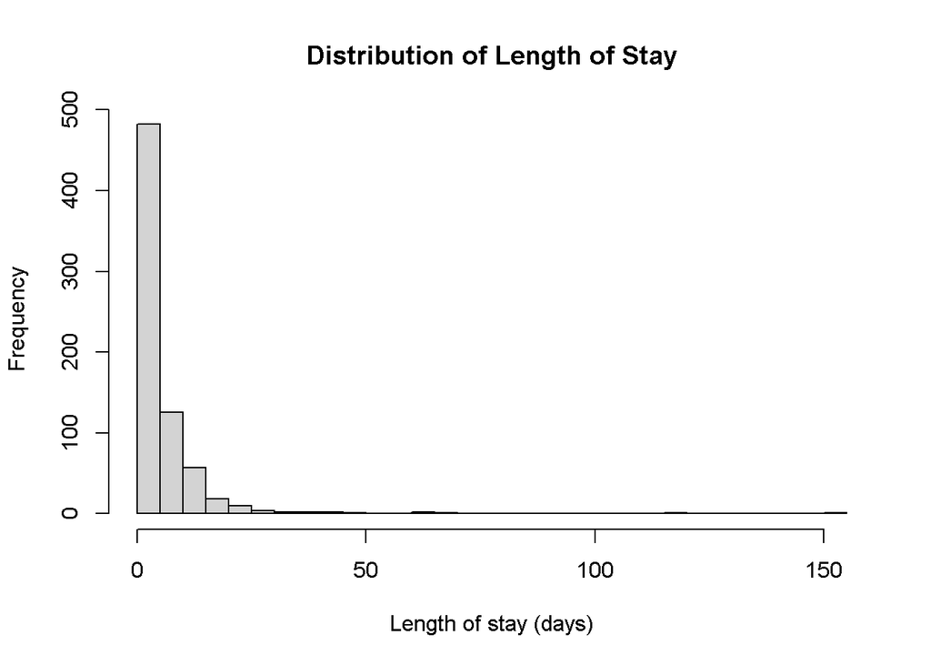

```r
hist(
  cohort_inpatient$length_of_stay_days,
  breaks = 30,
  main = "Distribution of Length of Stay",
  xlab = "Length of stay (days)"
)
```

```r
wilcox.test(length_of_stay_days ~ timing_group_main, data = cohort_inpatient)
```

```
##
##  Wilcoxon rank sum test with continuity correction
##
## data:  length_of_stay_days by timing_group_main
## W = 58083, p-value = 0.8384
## alternative hypothesis: true location shift is not equal to 0
```

```r
# Summary by 3-group timing bands
cohort_inpatient %>%
  group_by(timing_group) %>%
  summarise(
    n = n(),
    median_stay = median(length_of_stay_days, na.rm = TRUE),
    iqr_low = quantile(length_of_stay_days, 0.25, na.rm = TRUE),
    iqr_high = quantile(length_of_stay_days, 0.75, na.rm = TRUE)
  )
```

| timing_group | n | median_stay | iqr_low | iqr_high |
| --- | --- | --- | --- | --- |
| 0-30 | 455 | 3 | 2 | 7 |
| 31-60 | 188 | 3 | 2 | 7 |
| 61-120 | 65 | 3 | 2 | 8 |

```r
kruskal.test(length_of_stay_days ~ timing_group, data = cohort_inpatient)
```

```
##
##  Kruskal-Wallis rank sum test
##
## data:  length_of_stay_days by timing_group
## Kruskal-Wallis chi-squared = 2.8678, df = 2, p-value = 0.2384
```

Median LOS was 3 days (IQR 2–7) in both primary timing groups, with no significant differences (Wilcoxon p = 0.838 for 2 groups; Kruskal–Wallis p = 0.238 across 3 timing bands).

## 11.5 Operative case duration (primary outcome)

Operative case duration (ProcedureStartInstant to ProcedureCompleteInstant in minutes) is the primary outcome. I summarized duration by timing group and used Wilcoxon and Kruskal–Wallis tests because the distribution is skewed and includes an extreme outlier.

```r
# cohort_final <- cohort_final %>% filter(case_duration_min<1000)

# Summary by 2-group timing exposure
cohort_final %>%
  group_by(timing_group_main) %>%
  summarise(
    n = n(),
    median_duration = median(case_duration_min, na.rm = TRUE),
    iqr_low = quantile(case_duration_min, 0.25, na.rm = TRUE),
    iqr_high = quantile(case_duration_min, 0.75, na.rm = TRUE)
  )
```

| timing_group_main | n | median_duration | iqr_low | iqr_high |
| --- | --- | --- | --- | --- |
| 0-30 | 566 | 162.5 | 71.25 | 240 |
| 31-120 | 260 | 212.0 | 142.00 | 277 |

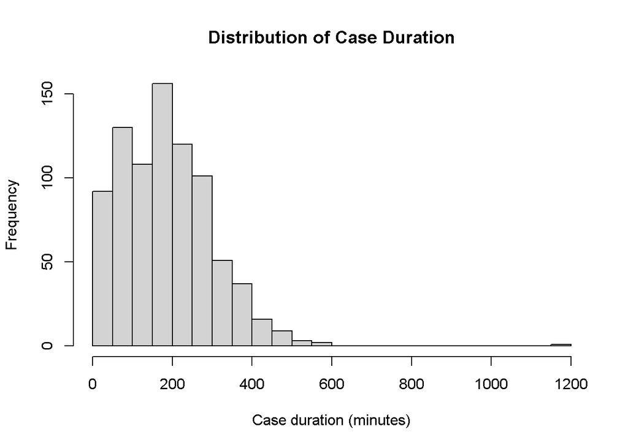

```r
hist(
  cohort_final$case_duration_min,
  breaks = 30,
  main = "Distribution of Case Duration",
  xlab = "Case duration (minutes)"
)
```

```r
# Wilcoxon test (2 groups)
wilcox.test(case_duration_min ~ timing_group_main, data = cohort_final)
```

```
##
##  Wilcoxon rank sum test with continuity correction
##
## data:  case_duration_min by timing_group_main
## W = 54883, p-value = 4.329e-09
## alternative hypothesis: true location shift is not equal to 0
```

```r
# Summary by 3-group timing bands
cohort_final %>%
  group_by(timing_group) %>%
  summarise(
    n = n(),
    median_duration = median(case_duration_min, na.rm = TRUE),
    iqr_low = quantile(case_duration_min, 0.25, na.rm = TRUE),
    iqr_high = quantile(case_duration_min, 0.75, na.rm = TRUE)
  )
```

| timing_group | n | median_duration | iqr_low | iqr_high |
| --- | --- | --- | --- | --- |
| 0-30 | 566 | 162.5 | 71.25 | 240.00 |
| 31-60 | 194 | 204.5 | 140.00 | 272.25 |
| 61-120 | 66 | 234.5 | 150.75 | 284.00 |

```r
# Kruskal–Wallis test (3 groups)
kruskal.test(case_duration_min ~ timing_group, data = cohort_final)
```

```
##
##  Kruskal-Wallis rank sum test
##
## data:  case_duration_min by timing_group
## Kruskal-Wallis chi-squared = 36.103, df = 2, p-value = 1.446e-08
```

### 11.5.1 Boxplot of case duration by timing group

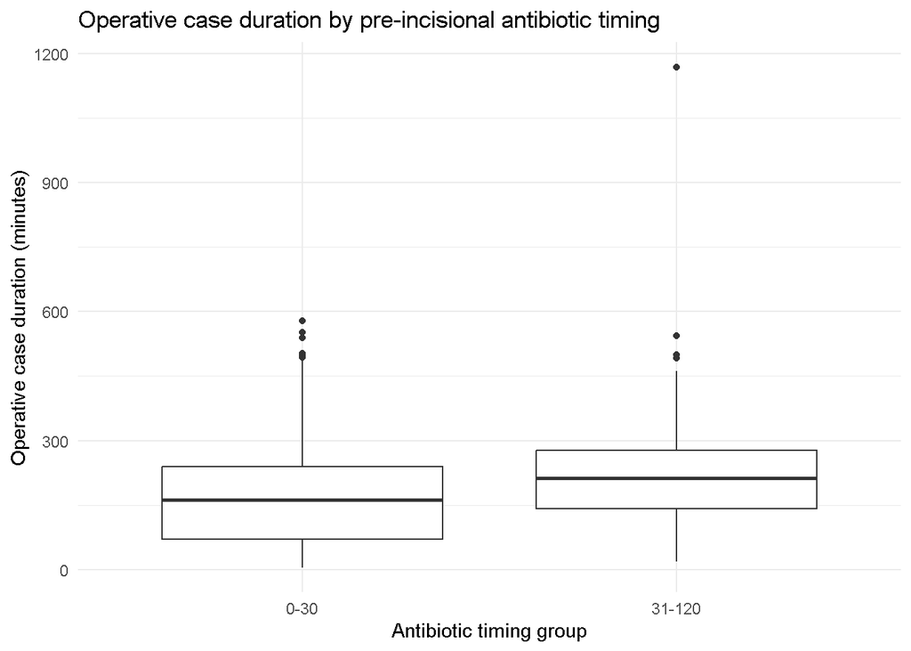

```r
cohort_final %>%
  ggplot(aes(x = timing_group_main, y = case_duration_min)) +
  geom_boxplot() +
  labs(
    x = "Antibiotic timing group",
    y = "Operative case duration (minutes)",
    title = "Operative case duration by pre-incisional antibiotic timing"
  ) +
  theme_minimal()
```

### Plot

```r
cohort_final_no_outlier <- cohort_final %>% filter(case_duration_min<1000)

# cohort_final %>%
#   group_by(antibiotic_class) %>%
#   summarise(
#     n = n(),
#     median_duration = median(case_duration_min, na.rm = TRUE),
#     iqr_low = quantile(case_duration_min, 0.25, na.rm = TRUE),
#     iqr_high = quantile(case_duration_min, 0.75, na.rm = TRUE)
#   )

cohort_final %>%
  group_by(antibiotic_class, timing_group_main) %>%
  summarise(
    n = n(),
    median_case_duration = median(case_duration_min, na.rm = TRUE),
    q1 = quantile(case_duration_min, 0.25, na.rm = TRUE),
    q3 = quantile(case_duration_min, 0.75, na.rm = TRUE),
    .groups = "drop"
  )
```

| antibiotic_class | timing_group_main | n | median_case_duration | q1 | q3 |
| --- | --- | --- | --- | --- | --- |
| Cefazolin | 0-30 | 256 | 121 | 57.50 | 201.25 |
| Cefazolin | 31-120 | 97 | 188 | 121.00 | 247.00 |
| Vancomycin | 0-30 | 310 | 181 | 97.25 | 265.50 |
| Vancomycin | 31-120 | 163 | 230 | 154.00 | 288.00 |

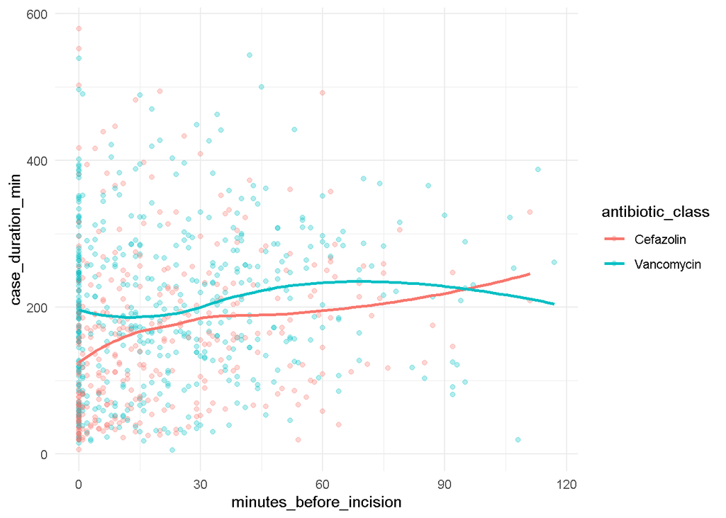

```r
ggplot(cohort_final_no_outlier, aes(
  x = minutes_before_incision,
  y = case_duration_min,
  color = antibiotic_class
)) +
  geom_point(alpha = 0.3) +
  geom_smooth(method = "loess", se = FALSE) +
  theme_minimal()
```

### 11.5.2 Regression Analysis

```r
cohort_final
```

| SurgicalCaseKey | PatientDurableKey | EncounterKey | SurgeryDateKeyValue | ProcedureStartInstant | ProcedureCompleteInstant | case_duration_min | antibiotic_instant | minutes_before_incision | antibiotic_name | antibiotic_class | rn | timing_group | AdmissionPatientClass | Sex | RaceEthnicity | BirthDate | Age | timing_group_main | diabetes | hypertension | obesity | smoking | cancer | preop_wbc | preop_wbc_date | preop_wbc_unit | preop_hgb | preop_hgb_date | preop_hgb_unit | … |
| --- | --- | --- | --- | --- | --- | --- | --- | --- | --- | --- | --- | --- | --- | --- | --- | --- | --- | --- | --- | --- | --- | --- | --- | --- | --- | --- | --- | --- | --- | --- |
| DCD9B8C2BFBA71 | DD53E5BE19AB03 | DFB3EE33B8DAD2 | 2022-02-26 | 2022-02-26 18:10:00 | 2022-02-26 21:41:00 | 211 | 2022-02-26 17:59:00 | 11 | ceFAZolin 1 gram solution for injection | Cefazolin | 1 | 0-30 | Inpatient | Female | White | 1966-07-03 | 55.65229 | 0-30 | 0 | 0 | 0 | 0 | 0 | NA |  | NA | NA |  | NA | … |
| DCE9180A202473 | DABCD162167625 | D280B35C223AC8 | 2020-05-06 | 2020-05-06 14:49:00 | 2020-05-06 19:57:00 | 308 | 2020-05-06 14:00:00 | 49 | vancomycin 500 mg intravenous solution | Vancomycin | 1 | 31-60 | Inpatient | Male | White | 1982-11-02 | 37.50856 | 31-120 | 0 | 0 | 0 | 0 | 0 | 11.7 | 2020-05-05 | x10E9/L | 10.8 | 2020-05-05 | g/dL | … |
| DCEAFDF26C1191 | D381F164C16BF3 | D149EABDB785A8 | 2021-06-22 | 2021-06-22 09:34:00 | 2021-06-22 14:01:00 | 267 | 2021-06-22 09:13:00 | 21 | vancomycin 500 mg intravenous solution | Vancomycin | 1 | 0-30 | Inpatient | Male | Latinx | 1957-11-10 | 63.61396 | 0-30 | 0 | 1 | 0 | 0 | 1 | 7.3 | 2021-06-21 | x10E9/L | 14.4 | 2021-06-21 | g/dL | … |
| DCEC9941ECEF71 | D34773191D2CE8 | D1C67B5CDA928A | 2020-03-26 | 2020-03-26 09:54:00 | 2020-03-26 12:40:00 | 166 | 2020-03-26 09:37:00 | 17 | vancomycin 500 mg intravenous solution | Vancomycin | 1 | 0-30 | Inpatient | Female | White | 1963-05-25 | 56.83778 | 0-30 | 0 | 0 | 0 | 0 | 1 | 4.6 | 2020-03-25 | x10E9/L | 13.8 | 2020-03-25 | g/dL | … |
| DCF70544DC44DA | D649EA935D0065 | DF72E4436AFE96 | 2021-01-22 | 2021-01-22 08:44:00 | 2021-01-22 10:17:00 | 93 | 2021-01-22 08:22:00 | 22 | vancomycin 500 mg intravenous solution | Vancomycin | 1 | 0-30 | Inpatient | Female | White | 1977-10-21 | 43.25530 | 0-30 | 0 | 0 | 0 | 0 | 1 | 17.9 | 2021-01-18 | Thousand/uL | 15.7 | 2021-01-18 | g/dL | … |
| DCFCDC24A11F2B | DCBE8A891A5B86 | D3169EFF86718E | 2020-09-22 | 2020-09-22 13:42:00 | 2020-09-22 16:42:00 | 180 | 2020-09-22 13:00:00 | 42 | vancomycin 500 mg intravenous solution | Vancomycin | 1 | 31-60 | Inpatient | Male | White | 1988-03-05 | 32.55031 | 31-120 | 0 | 0 | 0 | 0 | 0 | 6.0 | 2020-09-21 | x10E9/L | 15.5 | 2020-09-21 | g/dL | … |
| DCFF70F6CBBDBF | D0286D48B0A0BE | DB20CEE388F85A | 2020-07-19 | 2020-07-19 10:17:00 | 2020-07-19 10:48:00 | 31 | 2020-07-19 10:17:00 | 0 | ceFAZolin 1 gram solution for injection | Cefazolin | 1 | 0-30 | Inpatient | Male | White | 1950-08-06 | 69.95209 | 0-30 | 0 | 0 | 0 | 0 | 0 | 8.1 | 2020-06-26 | Thousand/uL | 14.9 | 2020-06-26 | g/dL | … |
| DCFF9CC0A6CE98 | DCD387DA008180 | D47C76154D0E79 | 2021-05-07 | 2021-05-07 14:36:00 | 2021-05-07 15:58:00 | 82 | 2021-05-07 14:35:00 | 1 | ceFAZolin 1 gram solution for injection | Cefazolin | 1 | 0-30 | Inpatient | Male | Black or African American | 1963-07-03 | 57.84531 | 0-30 | 0 | 0 | 0 | 0 | 1 | 12.1 | 2021-04-26 | x10E9/L | 15.6 | 2021-04-26 | g/dL | … |
| DD046B44FBCDC7 | D59A96BED7718A | D5F5A958A55D5F | 2020-08-11 | 2020-08-11 14:03:00 | 2020-08-11 18:25:00 | 262 | 2020-08-11 13:13:00 | 50 | vancomycin 500 mg intravenous solution | Vancomycin | 1 | 31-60 | Inpatient | Female | Black or African American | 1960-06-07 | 60.17796 | 31-120 | 0 | 1 | 0 | 1 | 0 | 8.5 | 2020-08-10 | x10E9/L | 14.5 | 2020-08-10 | g/dL | … |
| DD0912E834DD0D | DD2D13A6E92479 | D85B63612B46F6 | 2020-11-20 | 2020-11-20 12:07:00 | 2020-11-20 19:28:00 | 441 | 2020-11-20 11:32:00 | 35 | vancomycin 500 mg intravenous solution | Vancomycin | 1 | 31-60 | Inpatient | Female | White | 1973-08-16 | 47.26352 | 31-120 | 1 | 1 | 0 | 0 | 1 | 9.1 | 2020-11-19 | x10E9/L | 12.8 | 2020-11-19 | g/dL | … |

[output cut: 816 more lines]

```r
kruskal.test(case_duration_min ~ antibiotic_class, data = cohort_final)
```

```
##
##  Kruskal-Wallis rank sum test
##
## data:  case_duration_min by antibiotic_class
## Kruskal-Wallis chi-squared = 37.308, df = 1, p-value = 1.009e-09
```

```r
model_duration <- lm(
  log(case_duration_min) ~ timing_group_main + antibiotic_class + Age + Sex + diabetes,
  data = cohort_final
)

summary(model_duration)
```

```
##
## Call:
## lm(formula = log(case_duration_min) ~ timing_group_main + antibiotic_class +
##     Age + Sex + diabetes, data = cohort_final)
##
## Residuals:
##     Min      1Q  Median      3Q     Max
## -3.3036 -0.4260  0.1461  0.5130  1.7232
##
## Coefficients:
##                             Estimate Std. Error t value Pr(>|t|)
## (Intercept)                 5.010299   0.095095  52.687  < 2e-16 ***
## timing_group_main31-120     0.335930   0.054644   6.148 1.23e-09 ***
## antibiotic_classVancomycin  0.294171   0.051273   5.737 1.35e-08 ***
## Age                        -0.005237   0.001507  -3.475 0.000538 ***
## SexMale                    -0.012660   0.050759  -0.249 0.803103
## diabetes                    0.003110   0.096968   0.032 0.974426
## ---
## Signif. codes:  0 '***' 0.001 '**' 0.01 '*' 0.05 '.' 0.1 ' ' 1
##
## Residual standard error: 0.7266 on 820 degrees of freedom
## Multiple R-squared:  0.09842,    Adjusted R-squared:  0.09292
## F-statistic:  17.9 on 5 and 820 DF,  p-value: < 2.2e-16
```